# Assigment 01

Christian Regensius

5/10/2019

Congratulations! You have completed Programming for Data Science course. To provide complete score for your report, you need to submit Learn By Building Module for Programming for Data Science. You’ll need submit one project to get the score for this track. The second project option, however is marked as optional.

# Project 1

Reproducible Data Science: create R Markdown file to report your business recommendation based on your data. This Rmarkdown combines :

## Task 1

1. Markdown title, author name, date

## Task 2

2. Add formatting styles and hierarchical structure in your markdown (such as add title using # head, subtitle using ##, add tabset, etc)

## Task 3

3. Data Explanation

Data terdiri dari: Row.ID = ID baris Order.ID = Transaksi data Order.Date = Tanggal transaksi Ship.Date = Tanggal pengiriman Customer.ID = ID Customer Segment = kategori customer Product.ID = ID produk Category = kategori produk Sub.Category = sub kategori produk Product.Name = nama produk Sales = nilai sales sub produk masing-masing transaksi Quantity = jumlah produk yang dibeli Discount = diskon yang diberikan transaksi Profit = profit per transaksi

## Task 4

4. read your data into R

```r
retail <- read.csv("data_input/retail.csv")
```

## Task 5

5. Step-by-step data transformation code with some expalanatory text (contain ‘chunk’ and also the markdown)

Cek summary isi data, untuk mendapatkan sense awal tentang data yang sudah dibaca.

```r
summary(retail)
```

```
##      Row.ID               Order.ID       Order.Date      Ship.Date
##  Min.   :   1   CA-2017-100111:  14   9/5/16  :  38   12/16/15:  35
##  1st Qu.:2499   CA-2017-157987:  12   9/2/17  :  36   9/26/17 :  34
##  Median :4998   CA-2016-165330:  11   11/10/16:  35   11/21/17:  32
##  Mean   :4998   US-2016-108504:  11   12/1/17 :  34   12/6/17 :  32
##  3rd Qu.:7496   CA-2015-131338:  10   12/2/17 :  34   12/12/17:  30
##  Max.   :9994   CA-2016-105732:  10   12/9/17 :  33   9/15/17 :  30
##                 (Other)       :9926   (Other) :9784   (Other) :9801
##           Ship.Mode      Customer.ID          Segment
##  First Class   :1538   WB-21850:  37   Consumer   :5191
##  Same Day      : 543   JL-15835:  34   Corporate  :3020
##  Second Class  :1945   MA-17560:  34   Home Office:1783
##  Standard Class:5968   PP-18955:  34
##                        CK-12205:  32
##                        EH-13765:  32
##                        (Other) :9791
##            Product.ID              Category         Sub.Category
##  OFF-PA-10001970:  19   Furniture      :2121   Binders    :1523
##  TEC-AC-10003832:  18   Office Supplies:6026   Paper      :1370
##  FUR-FU-10004270:  16   Technology     :1847   Furnishings: 957
##  FUR-CH-10001146:  15                          Phones     : 889
##  FUR-CH-10002647:  15                          Storage    : 846
##  TEC-AC-10002049:  15                          Art        : 796
##  (Other)        :9896                          (Other)    :3613
##                      Product.Name      Sales              Quantity
##  Staple envelope           :  48   Min.   :    0.444   Min.   : 1.00
##  Easy-staple paper         :  46   1st Qu.:   17.280   1st Qu.: 2.00
##  Staples                   :  46   Median :   54.490   Median : 3.00
##  Avery Non-Stick Binders   :  20   Mean   :  229.858   Mean   : 3.79
##  Staples in misc. colors   :  19   3rd Qu.:  209.940   3rd Qu.: 5.00
##  KI Adjustable-Height Table:  18   Max.   :22638.480   Max.   :14.00
##  (Other)                   :9797
##     Discount          Profit
##  Min.   :0.0000   Min.   :-6599.978
##  1st Qu.:0.0000   1st Qu.:    1.729
##  Median :0.2000   Median :    8.666
##  Mean   :0.1562   Mean   :   28.657
##  3rd Qu.:0.2000   3rd Qu.:   29.364
##  Max.   :0.8000   Max.   : 8399.976
##
```

Sekilas cek beberapa data untuk menambah pemahaman kita terhadap data yang kita baca

```r
head(retail)
```

```
##   Row.ID       Order.ID Order.Date Ship.Date      Ship.Mode Customer.ID
## 1      1 CA-2016-152156    11/8/16  11/11/16   Second Class    CG-12520
## 2      2 CA-2016-152156    11/8/16  11/11/16   Second Class    CG-12520
## 3      3 CA-2016-138688    6/12/16   6/16/16   Second Class    DV-13045
## 4      4 US-2015-108966   10/11/15  10/18/15 Standard Class    SO-20335
## 5      5 US-2015-108966   10/11/15  10/18/15 Standard Class    SO-20335
## 6      6 CA-2014-115812     6/9/14   6/14/14 Standard Class    BH-11710
##     Segment      Product.ID        Category Sub.Category
## 1  Consumer FUR-BO-10001798       Furniture    Bookcases
## 2  Consumer FUR-CH-10000454       Furniture       Chairs
## 3 Corporate OFF-LA-10000240 Office Supplies       Labels
## 4  Consumer FUR-TA-10000577       Furniture       Tables
## 5  Consumer OFF-ST-10000760 Office Supplies      Storage
## 6  Consumer FUR-FU-10001487       Furniture  Furnishings
##                                                       Product.Name
## 1                                Bush Somerset Collection Bookcase
## 2      Hon Deluxe Fabric Upholstered Stacking Chairs, Rounded Back
## 3        Self-Adhesive Address Labels for Typewriters by Universal
## 4                    Bretford CR4500 Series Slim Rectangular Table
## 5                                   Eldon Fold 'N Roll Cart System
## 6 Eldon Expressions Wood and Plastic Desk Accessories, Cherry Wood
##      Sales Quantity Discount    Profit
## 1 261.9600        2     0.00   41.9136
## 2 731.9400        3     0.00  219.5820
## 3  14.6200        2     0.00    6.8714
## 4 957.5775        5     0.45 -383.0310
## 5  22.3680        2     0.20    2.5164
## 6  48.8600        7     0.00   14.1694
```

Cek tipe data apakah sudah sesuai dengan data yang ada atau belum.

```r
str(retail)
```

```
## 'data.frame':    9994 obs. of  15 variables:
##  $ Row.ID      : int  1 2 3 4 5 6 7 8 9 10 ...
##  $ Order.ID    : Factor w/ 5009 levels "CA-2014-100006",..: 2501 2501 2297 4373 4373 202 202 202 202 202 ...
##  $ Order.Date  : Factor w/ 1237 levels "1/1/17","1/10/14",..: 305 305 836 94 94 922 922 922 922 922 ...
##  $ Ship.Date   : Factor w/ 1334 levels "1/1/15","1/1/16",..: 220 220 907 129 129 897 897 897 897 897 ...
##  $ Ship.Mode   : Factor w/ 4 levels "First Class",..: 3 3 3 4 4 4 4 4 4 4 ...
##  $ Customer.ID : Factor w/ 793 levels "AA-10315","AA-10375",..: 144 144 240 706 706 89 89 89 89 89 ...
##  $ Segment     : Factor w/ 3 levels "Consumer","Corporate",..: 1 1 2 1 1 1 1 1 1 1 ...
##  $ Product.ID  : Factor w/ 1862 levels "FUR-BO-10000112",..: 13 56 947 320 1317 186 563 1762 795 438 ...
##  $ Category    : Factor w/ 3 levels "Furniture","Office Supplies",..: 1 1 2 1 2 1 2 3 2 2 ...
##  $ Sub.Category: Factor w/ 17 levels "Accessories",..: 5 6 11 17 15 10 3 14 4 2 ...
##  $ Product.Name: Factor w/ 1850 levels "\"While you Were Out\" Message Book, One Form per Page",..: 387 833 1440 367 574 570 1137 1099 535 295 ...
##  $ Sales       : num  262 731.9 14.6 957.6 22.4 ...
##  $ Quantity    : int  2 3 2 5 2 7 4 6 3 5 ...
##  $ Discount    : num  0 0 0 0.45 0.2 0 0 0.2 0.2 0 ...
##  $ Profit      : num  41.91 219.58 6.87 -383.03 2.52 ...
```

Dari data yang dibaca dinilai beberapa tidak sesuai tipe datanya, dengan penjelasan sebagai berikut: 1. Data order.ID merupakan informasi untuk mengidentifikasi order. Hasil read mengidentifikasi order.ID sebagai factor, dimana order.ID ini tidak bersifat kategorikal dan juga tidak bersifat data kategorikal yang terurut. Oleh karena itu, lebih tepat untuk menyesuaikan data ini menjadi tipe data character. 2. Data order.date merupakan informasi untuk mengidentifikasi tanggal order. Hasil read mengidentifikasi order.date sebagai factor, dimana order.date ini menyimpan informasi tanggal. Oleh karena itu, lebih tepat untuk menyesuaikan data ini menjadi tipe data date. 3. Data ship.date merupakan informasi untuk mengidentifikasi tanggal pengiriman . Hasil read mengidentifikasi ship.date sebagai factor, dimana ship.date ini menyimpan informasi tanggal. Oleh karena itu, lebih tepat untuk menyesuaikan data ini menjadi tipe data date. 4. Data produk.ID merupakan informasi untuk mengidentifikasi produk. Hasil read mengidentifikasi produk.ID sebagai factor, dimana produk.ID ini tidak bersifat kategorikal dan juga tidak bersifat data kategorikal yang terurut. Oleh karena itu, lebih tepat untuk menyesuaikan data ini menjadi tipe data character.

Sesuaikan masing-masing kolom dengan tipe data yang dinilai lebih tepat, antara lain seperti berikut:

1. Mengubah order ID menjadi karakter.

```r
retail$Order.ID <- as.character(retail$Order.ID)
```

2. Mengubah order Date menjadi tanggal sesuai format R. Dari data yang dibaca, format tanggalnya yaitu %m/%d/y

```r
retail$Order.Date <- as.Date(retail$Order.Date, format = "%m/%d/%y")
```

3. Mengubah ship Date menjadi tanggal sesuai format R. Dari data yang dibaca, format tanggalnya yaitu %m/%d/y

```r
retail$Ship.Date <- as.Date(retail$Ship.Date, format = "%m/%d/%y")
```

4. Mengubah produk ID menjadi karakter.

```r
retail$Product.ID <- as.character(retail$Product.ID)
```

Pastikan bahwa tipe data sudah sesuai

```r
str(retail)
```

```
## 'data.frame':    9994 obs. of  15 variables:
##  $ Row.ID      : int  1 2 3 4 5 6 7 8 9 10 ...
##  $ Order.ID    : chr  "CA-2016-152156" "CA-2016-152156" "CA-2016-138688" "US-2015-108966" ...
##  $ Order.Date  : Date, format: "2016-11-08" "2016-11-08" ...
##  $ Ship.Date   : Date, format: "2016-11-11" "2016-11-11" ...
##  $ Ship.Mode   : Factor w/ 4 levels "First Class",..: 3 3 3 4 4 4 4 4 4 4 ...
##  $ Customer.ID : Factor w/ 793 levels "AA-10315","AA-10375",..: 144 144 240 706 706 89 89 89 89 89 ...
##  $ Segment     : Factor w/ 3 levels "Consumer","Corporate",..: 1 1 2 1 1 1 1 1 1 1 ...
##  $ Product.ID  : chr  "FUR-BO-10001798" "FUR-CH-10000454" "OFF-LA-10000240" "FUR-TA-10000577" ...
##  $ Category    : Factor w/ 3 levels "Furniture","Office Supplies",..: 1 1 2 1 2 1 2 3 2 2 ...
##  $ Sub.Category: Factor w/ 17 levels "Accessories",..: 5 6 11 17 15 10 3 14 4 2 ...
##  $ Product.Name: Factor w/ 1850 levels "\"While you Were Out\" Message Book, One Form per Page",..: 387 833 1440 367 574 570 1137 1099 535 295 ...
##  $ Sales       : num  262 731.9 14.6 957.6 22.4 ...
##  $ Quantity    : int  2 3 2 5 2 7 4 6 3 5 ...
##  $ Discount    : num  0 0 0 0.45 0.2 0 0 0.2 0.2 0 ...
##  $ Profit      : num  41.91 219.58 6.87 -383.03 2.52 ...
```

Cek kembali summary data untuk meningkatkan pemahaman kita terkait data

```r
summary(retail)
```

```
##      Row.ID       Order.ID           Order.Date
##  Min.   :   1   Length:9994        Min.   :2014-01-03
##  1st Qu.:2499   Class :character   1st Qu.:2015-05-23
##  Median :4998   Mode  :character   Median :2016-06-26
##  Mean   :4998                      Mean   :2016-04-30
##  3rd Qu.:7496                      3rd Qu.:2017-05-14
##  Max.   :9994                      Max.   :2017-12-30
##
##    Ship.Date                   Ship.Mode      Customer.ID
##  Min.   :2014-01-07   First Class   :1538   WB-21850:  37
##  1st Qu.:2015-05-27   Same Day      : 543   JL-15835:  34
##  Median :2016-06-29   Second Class  :1945   MA-17560:  34
##  Mean   :2016-05-03   Standard Class:5968   PP-18955:  34
##  3rd Qu.:2017-05-18                         CK-12205:  32
##  Max.   :2018-01-05                         EH-13765:  32
##                                             (Other) :9791
##         Segment      Product.ID                   Category
##  Consumer   :5191   Length:9994        Furniture      :2121
##  Corporate  :3020   Class :character   Office Supplies:6026
##  Home Office:1783   Mode  :character   Technology     :1847
##
##
##
##
##       Sub.Category                      Product.Name      Sales
##  Binders    :1523   Staple envelope           :  48   Min.   :    0.444
##  Paper      :1370   Easy-staple paper         :  46   1st Qu.:   17.280
##  Furnishings: 957   Staples                   :  46   Median :   54.490
##  Phones     : 889   Avery Non-Stick Binders   :  20   Mean   :  229.858
##  Storage    : 846   Staples in misc. colors   :  19   3rd Qu.:  209.940
##  Art        : 796   KI Adjustable-Height Table:  18   Max.   :22638.480
##  (Other)    :3613   (Other)                   :9797
##     Quantity        Discount          Profit
##  Min.   : 1.00   Min.   :0.0000   Min.   :-6599.978
##  1st Qu.: 2.00   1st Qu.:0.0000   1st Qu.:    1.729
##  Median : 3.00   Median :0.2000   Median :    8.666
##  Mean   : 3.79   Mean   :0.1562   Mean   :   28.657
##  3rd Qu.: 5.00   3rd Qu.:0.2000   3rd Qu.:   29.364
##  Max.   :14.00   Max.   :0.8000   Max.   : 8399.976
##
```

# Task 6 - Insight

Exploratory text and business recommendation based on your own creativity**. Berikut adalah beberapa pertanyaan untuk menggali insight dari data retail.

### Bagaimana summary Profit dari data retail?

```r
#
summary(retail$Profit,object = )
```

```
##      Min.   1st Qu.    Median      Mean   3rd Qu.      Max.
## -6599.978     1.729     8.666    28.657    29.364  8399.976
```

### Kategori produk apa yang paling banyak dibeli oleh segment Corporate

```r
# melakukan tabulasi category dan segment
table(retail$Category, retail$Segment)
```

```
##
##                   Consumer Corporate Home Office
##   Furniture           1113       646         362
##   Office Supplies     3127      1820        1079
##   Technology           951       554         342
```

Intepretasi: Dari data disimpulkan bahwa segment corporate paling banyak membeli kategori produk “Office Supplies”

### Kategori produk apa dan segment apa yang menghasilkan profit di atas-rata keseluruhan?

```r
# men-subset data dengan profit lebih besar dari nilai mean
profit_above_mean <- retail[retail$Profit > mean(retail$Profit), ]

# membuat tabulasi berdasarkan category dan segment
table(profit_above_mean$Category, profit_above_mean$Segment)
```

```
##
##                   Consumer Corporate Home Office
##   Furniture            303       177          98
##   Office Supplies      537       348         214
##   Technology           455       256         163
```

Intepretasi: Dari tabel di atas disimpulkan bahwa penjualan dengan profit di atas rata-rata paling banyak adalah pada segment consumer dengan produk office supplies.

### Bagaimana sebaran profit secara keseluruhan?

```r
retail_profit_percent <- retail$Profit

# informasi deskriptif profit
summary(retail$Profit)
```

```
##      Min.   1st Qu.    Median      Mean   3rd Qu.      Max.
## -6599.978     1.729     8.666    28.657    29.364  8399.976
```

```r
#informasi nilai tertinggi dan nilai terendah dari data Profit
range(retail$Profit)
```

```
## [1] -6599.978  8399.976
```

```r
# informasi deskriptif sales
summary(retail$Sales)
```

```
##      Min.   1st Qu.    Median      Mean   3rd Qu.      Max.
##     0.444    17.280    54.490   229.858   209.940 22638.480
```

```r
#informasi nilai tertinggi dan nilai terendah dari data Sales
range(retail$Sales)
```

```
## [1]     0.444 22638.480
```

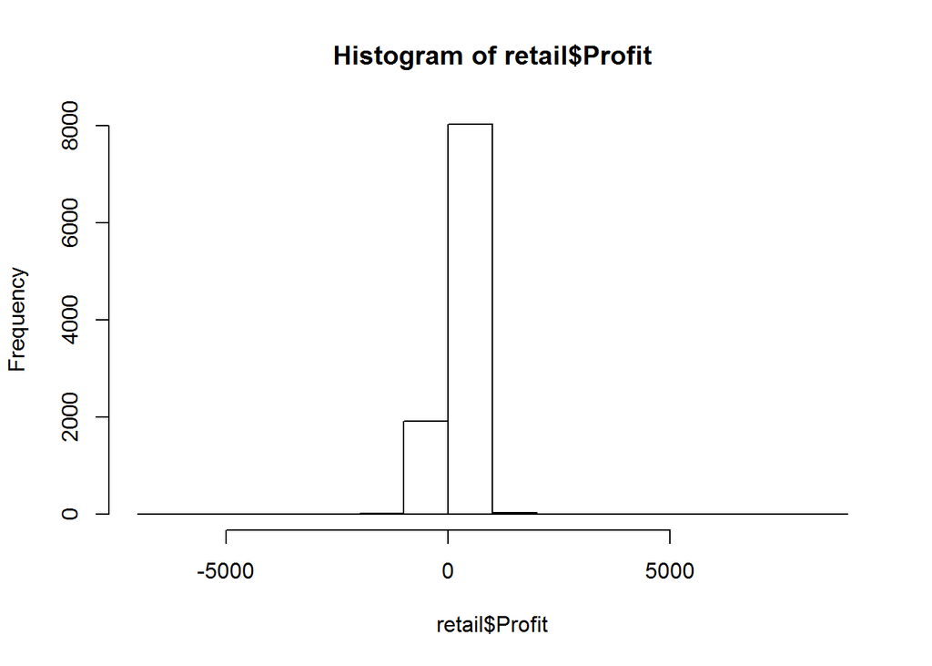

```r
# mengobservasi populasi data profit
hist(retail$Profit,20)
```

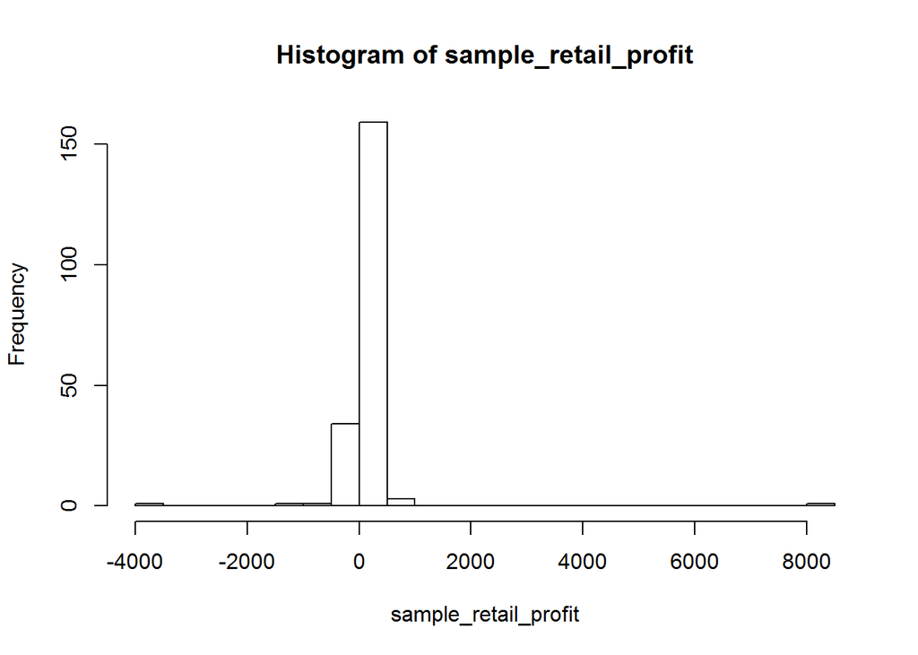

```r
# mensubset data dengan profit dengan sample size sebesar 200 data
sample_retail_profit <- sample(retail$Profit, 200)

# mengobservasi distribusi sample profit
hist(sample_retail_profit, 20)
```

Intepretasi: Berdasarkan perbandingan histogram sample & populasi, bisa disimpulkan bahwa kepadatan data profit mengumpul di sekitar 0.

### Segmen & Kategori produk mana dengan profit tertinggi secara keseluruhan?

```r
# Membuat tabel yang mentabulasi profit berdasarkan segment dan kategori.
xtabs(Profit~Segment+Category, retail)
```

```
##              Category
## Segment       Furniture Office Supplies Technology
##   Consumer     6991.079       56330.321  70797.810
##   Corporate    7584.816       40227.320  44166.998
##   Home Office  3875.378       25933.160  30490.141
```

Intepretasi: Berdasarkan tabel di atas, Consumer & Technology berkontribusi terbesar pada profit secara umum.